# 02 Excel for Data Science

Designed for Rachel

Harry Lu, dl947@cornell.edu

May/29/2022

HOME

# 1 Background

- Why using Excel for data science?
  - Good for starter learning concept of data science
  - Great editor for 2-D data
  - Do not need coding background
  - Built-in tools, access from button
  - Visualizations
  - More…
- What is the advantage?
  - Graphic UI
  - More…
- What is the disadvantage?
  - Not good for big data
  - Not good for complex computation
  - Hard to automate
  - More…

# 2 Basics of MS Excel

- Note: In the class note, all the demos would come from the Windows version. The Mac version may have a little bit difference in the UI, but all the functionalities should be the same.

## 2.1 Knowing the UI

- Download the sample data 1

[figure not shown]

- workbook
- worksheet, tab

## 2.2 Tool Area

### 2.2.1 Home

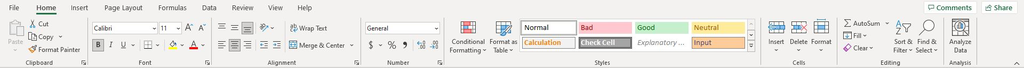

- Clipboard
  - paste without format
- Font
  - Table boarder
  - Background color
  - Text color
- Alignment
  - text wrapping
  - merge & un-merge cells
- Number
  - Adjusting number of decimal points
  - Adding/removing format: money, time, percentage
- Styles
  - Conditional formatting: data bar, color scale, customized rules
- Cells
  - insert column to left, row to top
  - lock cell, lock sheet
  - hide column
  - adjust row height, column width
- Editing
  - some commonly used functions
  - sort & order

### 2.2.2 Insert

[figure not shown]

- Tables
  - pivot table
  - auto format table
- Illustrations
  - draw shapes
  - smart art for flow chart
- Charts
  - bar chart
  - line chart
  - pie chart
  - scatter chart

### 2.2.3 Page Layout

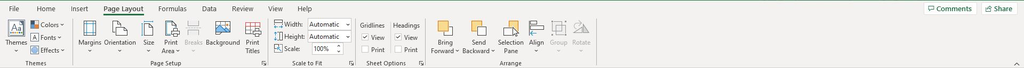

- Note: Normally not useful in data analytics.

### 2.2.4 Formulas

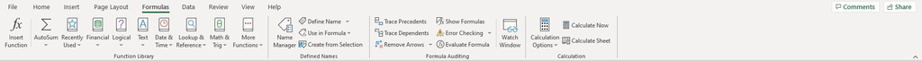

- Function Library
  - insert function (all functions)
  - auto sum
  - lookup
  - round

### 2.2.5 Data

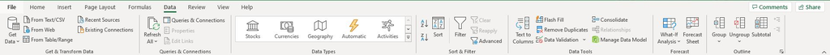

- Sort & Filter
  - filter by checkbox, filter by condition
  - sorted
- Data Tools
  - text to column, need to create empty column first
  - remove duplicates

### 2.2.6 Review

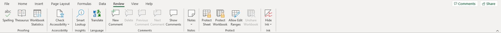

- Protect
  - lock workbook, lock worksheet, lock area

### 2.2.7 View

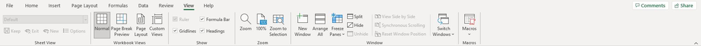

- Workbook Views
  - adjust page area

## 2.3 Functions

- Relative reference v.s. absolute reference

**Copyright © 2022 Harry Lu. All rights reserved.**